# Midterm Project

Vinay Warrier

# Midterm Project

**Render your final RMarkdown with answers in HTML format.**

**Project Objective:** This midterm project aims to analyze a dataset to gain insights, make data-driven decisions, and present your findings clearly and informally. Through this project, you will demonstrate your understanding of key data science principles and tools.

**Project Steps:**

1. **Choose a Dataset:** Select a dataset that is interesting to you and has potential for analysis. It could be related to any field, such as economics, social sciences, health, sports, or technology. Make sure the dataset is suitable for your skill level and project timeline.
2. **Data Acquisition:** Obtain the dataset from a reliable source. It could be sourced from public repositories, APIs, or provided by me. Ensure the data is in a format you can work with, such as CSV, Excel, or JSON.
3. **Data Cleaning:** Clean the dataset to handle missing values, outliers, and inconsistencies. This step is crucial as the quality of your analysis depends on the quality of your data. Document the cleaning steps you take.
4. **Exploratory Data Analysis (EDA):** Conduct exploratory analysis to understand the basic characteristics of the data. Calculate summary statistics, create visualizations (histograms, scatter plots, etc.), and identify patterns or trends.
5. **Interpretation and Conclusion:** Summarize your findings concisely and coherently. What insights did you gain from the data? How do your results address the initial objectives? Were there any unexpected discoveries?
6. **Project Report/Presentation:** Prepare a report or presentation that covers all the project steps. Include visuals, code snippets, and explanations to guide the reader through your process. Use precise language and avoid jargon.

**Project Grading:** Your project will be graded based on the following:

- Data acquisition and preprocessing
- Quality of exploratory analysis
- Clarity and accuracy of visualizations
- Soundness of conclusions drawn
- Overall presentation and documentation

Remember, data science is a blend of technical skills and domain knowledge coupled with the ability to communicate your findings effectively. This project aims to develop your skills in all these areas and provide you with a taste of what real-world data science involves.

Good luck, and please get in touch with me at hajoseph@scarletmail.rutgers.edu if you have any questions!

```r
#Start
epl_data <- read.csv("EPL_20_21.csv")

head(epl_data)
```

```
##                Name    Club Nationality Position Age Matches Starts Mins Goals
## 1       Mason Mount Chelsea         ENG    MF,FW  21      36     32 2890     6
## 2     Edouard Mendy Chelsea         SEN       GK  28      31     31 2745     0
## 3       Timo Werner Chelsea         GER       FW  24      35     29 2602     6
## 4      Ben Chilwell Chelsea         ENG       DF  23      27     27 2286     3
## 5       Reece James Chelsea         ENG       DF  20      32     25 2373     1
## 6 Cesar Azpilicueta Chelsea         ESP       DF  30      26     24 2188     1
##   Assists Passes_Attempted Perc_Passes_Completed Penalty_Goals
## 1       5             1881                  82.3             1
## 2       0             1007                  84.6             0
## 3       8              826                  77.2             0
## 4       5             1806                  78.6             0
## 5       2             1987                  85.0             0
## 6       2             2015                  87.5             0
##   Penalty_Attempted   xG   xA Yellow_Cards Red_Cards
## 1                 1 0.21 0.24            2         0
## 2                 0 0.00 0.00            2         0
## 3                 0 0.41 0.21            2         0
## 4                 0 0.10 0.11            3         0
## 5                 0 0.06 0.12            3         0
## 6                 0 0.03 0.11            5         1
```

```r
getmode <- function(v) {
   uniqv <- unique(v)
   uniqv[which.max(tabulate(match(v, uniqv)))]
}
```

```r
#Data Cleaning
check_missing_values <- colSums(is.na(epl_data))

check_missing_columns <- names(check_missing_values[check_missing_values > 0])
check_missing_columns
```

```
## character(0)
```

```r
summary(epl_data)
```

```
##      Name               Club           Nationality          Position
##  Length:532         Length:532         Length:532         Length:532
##  Class :character   Class :character   Class :character   Class :character
##  Mode  :character   Mode  :character   Mode  :character   Mode  :character
##
##
##
##       Age          Matches          Starts           Mins          Goals
##  Min.   :16.0   Min.   : 1.00   Min.   : 0.00   Min.   :   1   Min.   : 0.000
##  1st Qu.:22.0   1st Qu.: 9.00   1st Qu.: 4.00   1st Qu.: 426   1st Qu.: 0.000
##  Median :26.0   Median :21.00   Median :15.00   Median :1345   Median : 1.000
##  Mean   :25.5   Mean   :19.54   Mean   :15.71   Mean   :1411   Mean   : 1.853
##  3rd Qu.:29.0   3rd Qu.:30.00   3rd Qu.:27.00   3rd Qu.:2304   3rd Qu.: 2.000
##  Max.   :38.0   Max.   :38.00   Max.   :38.00   Max.   :3420   Max.   :23.000
##     Assists       Passes_Attempted Perc_Passes_Completed Penalty_Goals
##  Min.   : 0.000   Min.   :   0.0   Min.   : -1.00        Min.   :0.0000
##  1st Qu.: 0.000   1st Qu.: 171.5   1st Qu.: 73.50        1st Qu.:0.0000
##  Median : 0.000   Median : 573.5   Median : 79.20        Median :0.0000
##  Mean   : 1.288   Mean   : 717.8   Mean   : 77.82        Mean   :0.1917
##  3rd Qu.: 2.000   3rd Qu.:1129.5   3rd Qu.: 84.62        3rd Qu.:0.0000
##  Max.   :14.000   Max.   :3214.0   Max.   :100.00        Max.   :9.0000
##  Penalty_Attempted       xG               xA           Yellow_Cards
##  Min.   : 0.000    Min.   :0.0000   Min.   :0.00000   Min.   : 0.000
##  1st Qu.: 0.000    1st Qu.:0.0100   1st Qu.:0.00000   1st Qu.: 0.000
##  Median : 0.000    Median :0.0600   Median :0.05000   Median : 2.000
##  Mean   : 0.235    Mean   :0.1133   Mean   :0.07265   Mean   : 2.115
##  3rd Qu.: 0.000    3rd Qu.:0.1500   3rd Qu.:0.11000   3rd Qu.: 3.000
##  Max.   :10.000    Max.   :1.1600   Max.   :0.90000   Max.   :12.000
##    Red_Cards
##  Min.   :0.00000
##  1st Qu.:0.00000
##  Median :0.00000
##  Mean   :0.09023
##  3rd Qu.:0.00000
##  Max.   :2.00000
```

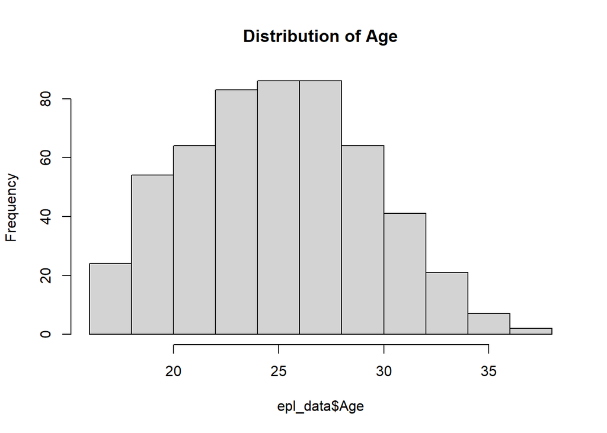

```r
#Sample Charts 1

hist(epl_data$Age, main = "Distribution of Age")
```

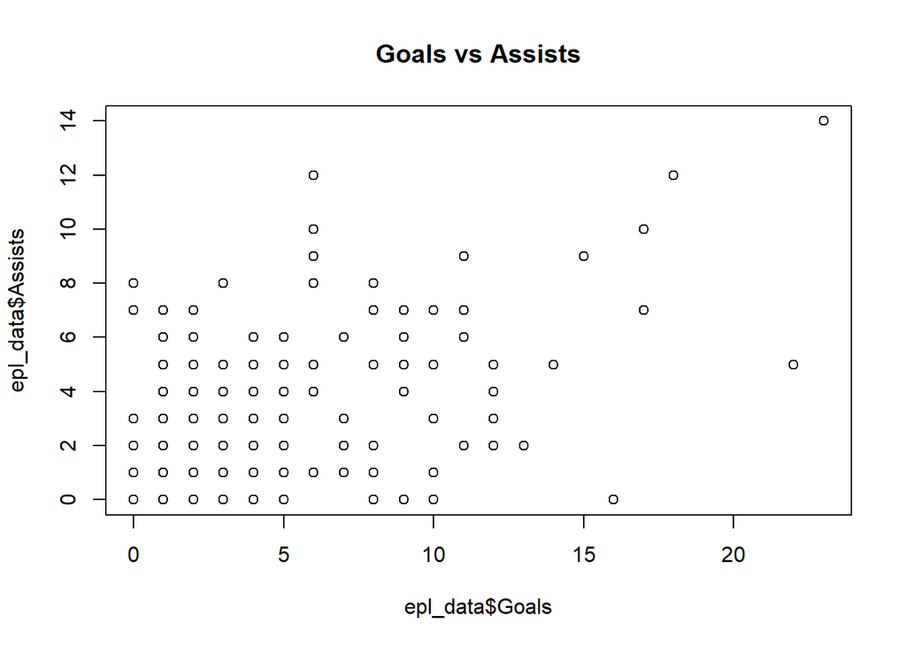

```r
plot(epl_data$Goals, epl_data$Assists, main = "Goals vs Assists")
```

```r
avg_goals <- mean(epl_data$Goals)
avg_assists <- mean(epl_data$Assists)
cat("On average, players scored", avg_goals, "goals and provided", avg_assists, "assists in the 2020-2021 EPL season.")
```

```
## On average, players scored 1.853383 goals and provided 1.287594 assists in the 2020-2021 EPL season.
```

```r
cat("These statistics provide insights into the overall offensive performance of players, aligning with our objective to analyze player performance in the EPL.")
```

```
## These statistics provide insights into the overall offensive performance of players, aligning with our objective to analyze player performance in the EPL.
```

```r
high_scorer <- epl_data$Name[which.max(epl_data$Goals)]
cat("Unexpectedly,", high_scorer, "emerged as the highest scorer in the dataset.")
```

```
## Unexpectedly, Harry Kane emerged as the highest scorer in the dataset.
```

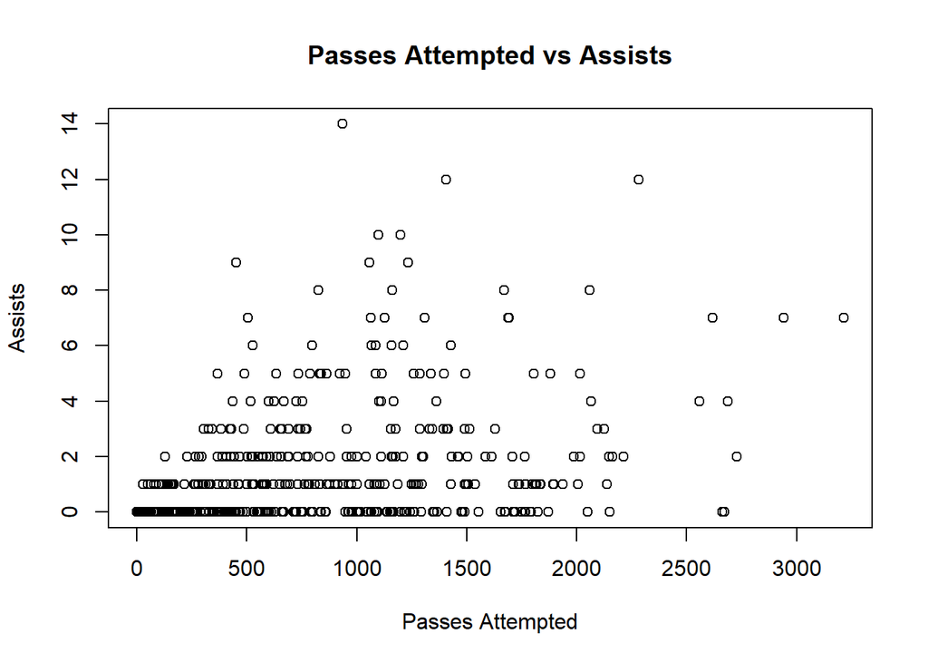

```r
#Sample Charts 2

scatter_passes_assists <- plot(epl_data$Passes_Attempted, epl_data$Assists, main = "Passes Attempted vs Assists", xlab = "Passes Attempted", ylab = "Assists")
```

```r
cat("The scatter plot shows a positive correlation between passes attempted and assists, suggesting that players who attempt more passes tend to have higher assist counts.")
```

```
## The scatter plot shows a positive correlation between passes attempted and assists, suggesting that players who attempt more passes tend to have higher assist counts.
```

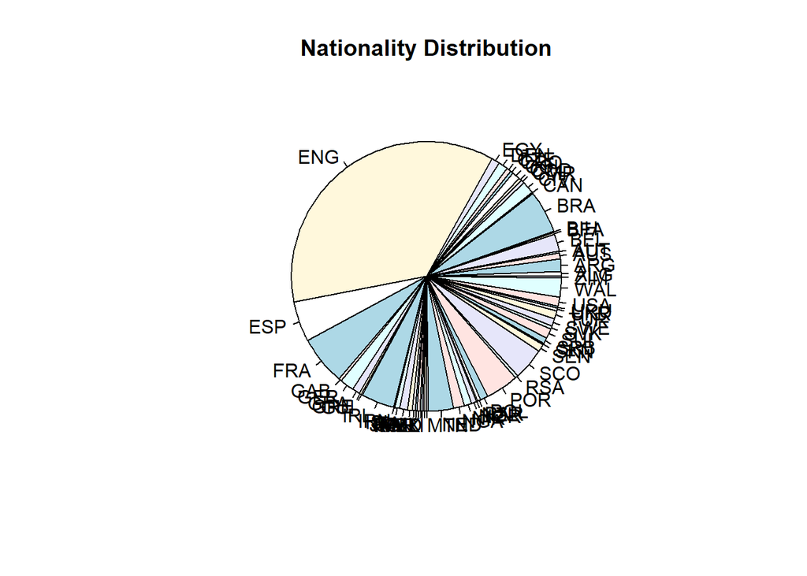

```r
nationality_pie <- pie(table(epl_data$Nationality), main = "Nationality Distribution")
```

```r
cat("The pie chart visualizes the distribution of players based on nationality, reflecting the international diversity in the English Premier League.")
```

```
## The pie chart visualizes the distribution of players based on nationality, reflecting the international diversity in the English Premier League.
```

```r
age_density_plot <- plot(density(epl_data$Age), main = "Density Plot of Age")
cat("The density plot showcases the distribution of player ages, with a peak around", round(mean(epl_data$Age), 2), "years. It provides insights into the age composition of players.")
```

```
## The density plot showcases the distribution of player ages, with a peak around 25.5 years. It provides insights into the age composition of players.
```

```r
library(GGally)
```

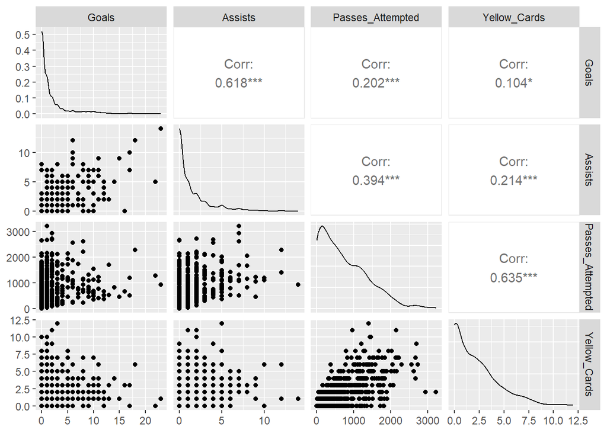

```r
pair_plot <- ggpairs(epl_data[, c("Goals", "Assists", "Passes_Attempted", "Yellow_Cards")])
pair_plot
```

```r
cat("The pair plot provides a comprehensive overview of pairwise relationships between key variables, helping identify patterns and potential outliers.")
```

```
## The pair plot provides a comprehensive overview of pairwise relationships between key variables, helping identify patterns and potential outliers.
```

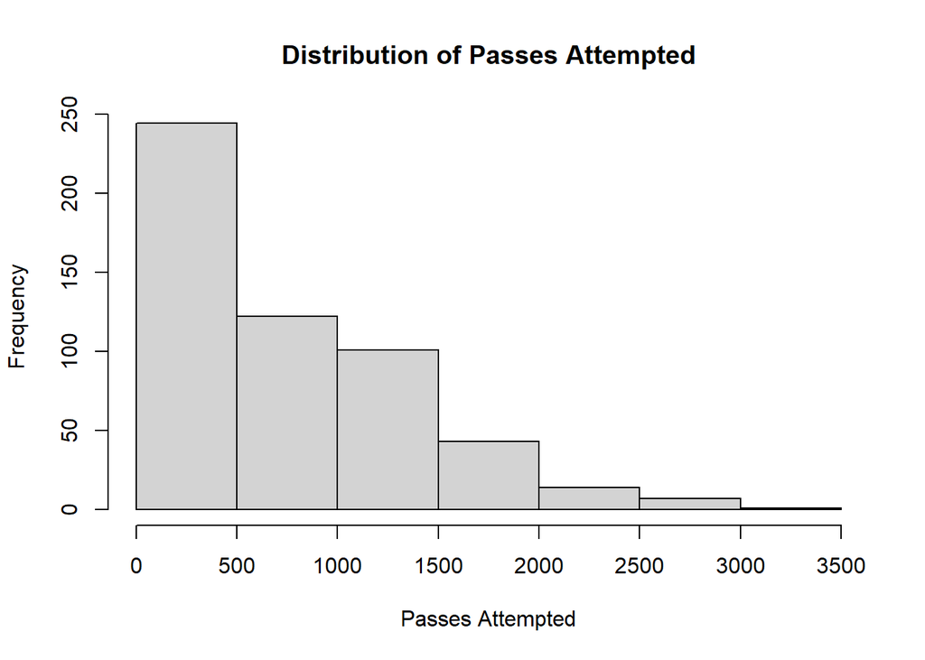

```r
# 1
passes_hist <- hist(epl_data$Passes_Attempted, main = "Distribution of Passes Attempted", xlab = "Passes Attempted")
```

```r
cat("The distribution of passes attempted by players shows", length(passes_hist$counts), "distinct intervals, indicating varying levels of player involvement in passing.")
```

```
## The distribution of passes attempted by players shows 7 distinct intervals, indicating varying levels of player involvement in passing.
```

```r
mean(epl_data$Passes_Attempted)
```

```
## [1] 717.75
```

```r
median(epl_data$Passes_Attempted)
```

```
## [1] 573.5
```

```r
getmode(epl_data$Passes_Attempted)
```

```
## [1] 1
```

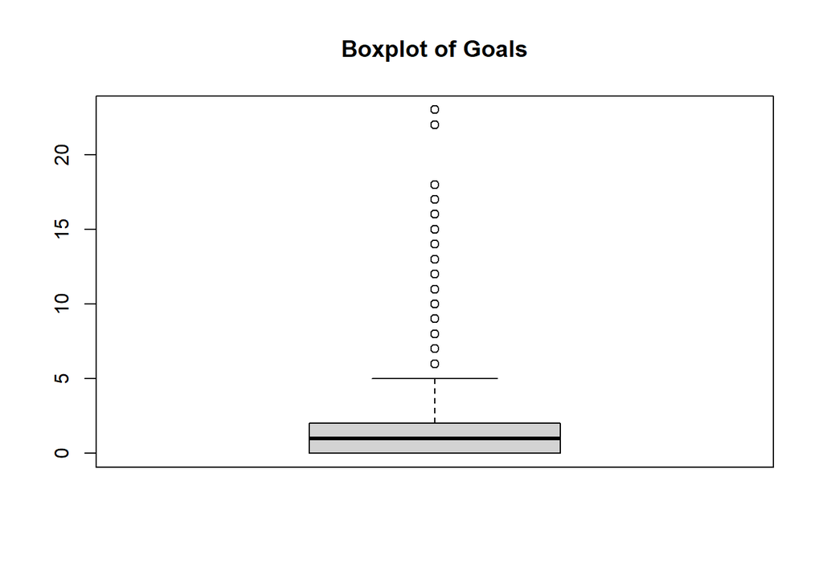

```r
# 2
goals_boxplot <- boxplot(epl_data$Goals, main = "Boxplot of Goals")
```

```r
cat("The box plot illustrates the spread of goal-scoring performances among players, with a median of", median(epl_data$Goals), "goals. It reveals the diversity in goal-scoring abilities.")
```

```
## The box plot illustrates the spread of goal-scoring performances among players, with a median of 1 goals. It reveals the diversity in goal-scoring abilities.
```

```r
median(epl_data$Goals)
```

```
## [1] 1
```

```r
quantile(epl_data$Goals, probs = c(0,0.25,0.5,0.75,1))
```

```
##   0%  25%  50%  75% 100%
##    0    0    1    2   23
```

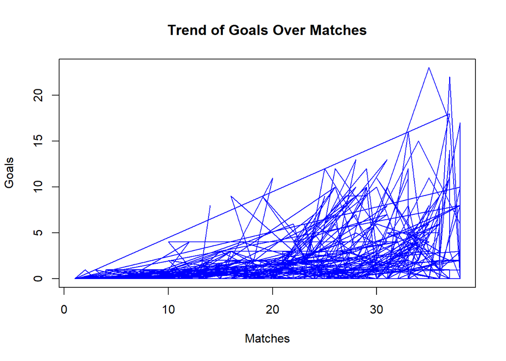

```r
plot(epl_data$Matches, epl_data$Goals, type = "l", col = "blue", xlab = "Matches", ylab = "Goals", main = "Trend of Goals Over Matches")
```

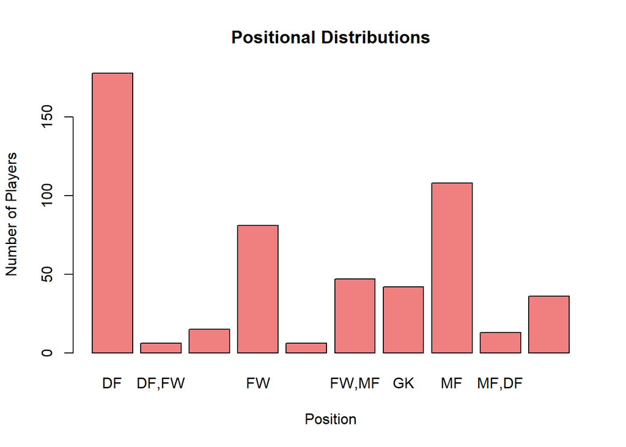

```r
# 3
position_counts <- table(epl_data$Position)
barplot(position_counts, main = "Positional Distributions", xlab = "Position", ylab = "Number of Players", col = "lightcoral", border = "black")
```

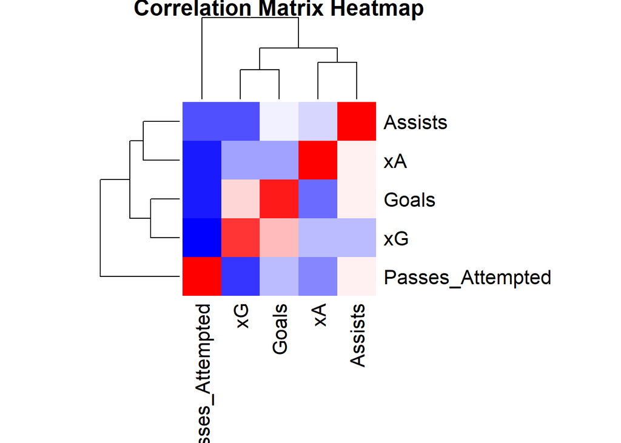

```r
#4

cor_matrix <- cor(epl_data[, c("Goals", "Assists", "Passes_Attempted", "xG", "xA")])
heatmap(cor_matrix, main = "Correlation Matrix Heatmap", col = colorRampPalette(c("blue", "white", "red"))(20), margins = c(10, 10))
```

```r
# 5
yellow_red_counts <- table(epl_data$Yellow_Cards, epl_data$Red_Cards)
barplot(yellow_red_counts, beside = TRUE, main = "Distribution of Yellow and Red Cards", xlab = "Number of Cards", ylab = "Number of Players", col = c("yellow", "red"), legend = TRUE)
```

[figure not shown]